# 432 Class 15

Thomas E. Love, Ph.D.

2025-03-04

## Today’s Agenda

- Data which describe time to an event
  - The Survival Function, S(t)
  - Kaplan-Meier Estimation of the Survival Function
  - Creating Survival Objects in R
  - Drawing Survival Curves with **survminer**

## Today’s R Setup

```r
knitr::opts_chunk$set(comment = NA)

library(janitor);
library(conflicted)
library(gt)
library(here)
library(mosaic)
library(survival)  ## new today
library(survminer) ## new today
library(easystats)
library(tidyverse)

theme_set(theme_bw())
conflicts_prefer(base::max, dplyr::filter)
```

# Introduction to Time-to-Event Data

## Working with Time to Event Data

In many medical studies, the main outcome variable is the time to the occurrence of a particular event.

- In a randomized controlled trial of cancer, for instance, surgery, radiation, and chemotherapy might be compared with respect to time from randomization and the start of therapy until death.

## Time-to-Event data

- In this case, the event of interest is the death of a patient, but in other situations it might be remission from a disease, relief from symptoms or the recurrence of a particular condition.
- Such observations are generally referred to by the generic term **survival data** even when the endpoint or event being considered is not death but something else.

## A First Example: Survival with AML

The `aml` data provided in the **survival** package describe survival times (in months) for 23 subjects with acute myelogenous leukemia.

Question: Should the standard course of chemotherapy be extended (maintained) for additional cycles or not?

- The study followed 11 subjects who received this maintenance chemotherapy, and 12 who did not, and tracked how long they survived (in months).
- But the problem was that 18 of the subjects were still alive at the time of their last follow-up.

## Data Ingest

I ingested the `aml` data from the **survival** package into a new tibble that I called `aml_432`, with 23 rows and 4 columns…

```r
aml_432 <- survival::aml |> tibble() |>
  rename(maintain = x, censored = status, months = time) |>
  arrange(desc(months)) |>
  mutate(subject = as.character(row_number())) |>
  relocate(subject)

head(aml_432)
```

```
# A tibble: 6 × 4
  subject months censored maintain
  <chr>    <dbl>    <dbl> <fct>
1 1          161        0 Maintained
2 2           48        1 Maintained
3 3           45        0 Maintained
4 4           45        1 Nonmaintained
5 5           43        1 Nonmaintained
6 6           34        1 Maintained
```

## The `aml_432` codebook

| `aml_432` | Description | *aml* |
| --- | --- | --- |
| `subject` | subject identifying code | – |
| `months` | known months of survival in follow-up period | *time* |
| `censored` | 1 if subject’s follow-up time was censored, else 0 | *status* |
| `maintain` | Chemotherapy was Maintained or “Nonmaintained” | *x* |

- If `censored` is 0, this means we know when the person died.

## What’s in a Time-to-Event Study?

Survival analysis is concerned with prospective studies. We start with a cohort of patients and follow them forwards in time to determine some clinical outcome.

- Follow-up continues until either some event of interest occurs, the study ends, or further observation becomes impossible.

## Time-to-Event (Survival) Outcomes

The outcomes in a survival analysis consist of the patient’s **fate** and **length of follow-up** at the end of the study.

- For some patients, the outcome of interest may not occur during follow-up.
- For such patients, whose follow-up time is *censored*, we know only that this event did not occur while the patient was being followed. We do not know whether or not it will occur at some later time.

## Two subjects from `aml_432`

```r
aml_432 |> filter(subject %in% c(1, 8)) |> gt() |>
  tab_options(table.font.size = 24) |>
  opt_stylize(style = 2, color = "blue")
```

| subject | months | censored | maintain |
| --- | --- | --- | --- |
| 1 | 161 | 0 | Maintained |
| 8 | 31 | 1 | Maintained |

- Subject 1 was part of the Maintained group, and survived 161 months, at which point they died.
- Subject 8 was in the Maintained group, and survived at least 31 months, but was then censored<sup>1</sup>.
[^1]: perhaps because the study ended, or they were lost to the investigators

## Two more subjects from `aml_432`

```r
aml_432 |> filter(subject %in% c(15, 22)) |> gt() |>
  tab_options(table.font.size = 24) |>
  opt_stylize(style = 2, color = "blue")
```

| subject | months | censored | maintain |
| --- | --- | --- | --- |
| 15 | 16 | 0 | Nonmaintained |
| 22 | 5 | 1 | Nonmaintained |

- Subject 15 was in the Nonmaintained group, and survived 16 months, and then died.
- Subject 22 was in the Nonmaintained group, and survived at least 5 months, but was then censored (so they were not followed further.)

## Problems with Time to Event Data

The primary problems are *censoring* and *non-Normality*…

1. At the completion of the study, some patients may not have reached the endpoint of interest (death, relapse, etc.). Consequently, the exact survival times are not known.
   - All that is known is that the survival times are greater than the amount of time the individual has been in the study.
   - The survival times of these individuals are said to be **censored** (precisely, they are right-censored).

## Problems with Time to Event Data

The primary problems are *censoring* and *non-Normality*…

2. Survival data are not symmetrically distributed. They will often appear positively skewed, with a few people surviving a very long time compared with the majority; so assuming a normal distribution will not be reasonable.

Next, we’ll define some special functions to build models that address these concerns.

## The Survival Function, $S(t)$

The **survival function**, $S(t)$ (sometimes called the survivor function) is the probability that the survival time, $T$, is greater than or equal to a particular time, $t$.

- $S(t)$ = proportion of people surviving to time $t$ or beyond

## If there’s no censoring, the survival function is easy to estimate

When there is no censoring, this function is easily estimated.

$$\hat{S}(t) = \frac{\# \mbox{ of subjects with survival times } \geq t}{n}$$

but this won’t work if there is censoring.

Even with censoring, the Kaplan-Meier approach essentially estimates the survival function by the number of patients alive at time $t$ divided by the total number of study subjects remaining at that time.

## Kaplan-Meier Estimator

The Kaplan-Meier estimator first orders the (unique) survival times from smallest to largest, then estimates the survival function at each unique survival time.

- The survival function at the second death time, $t_{(2)}$ is equal to the estimated probability of not dying at time $t_{(2)}$ conditional on the individual being still at risk at time $t_{(2)}$.

## Kaplan-Meier Estimator

1. Order the survival times from smallest to largest, where $t_{(j)}$ is the $j$th largest unique survival time, so we have…

$$t_{(1)} \leq t_{(2)} \leq t_{(3)} \leq ... t_{(n)}$$

## Kaplan-Meier Estimator

2. The Kaplan-Meier estimate of the survival function is

$$\hat{S}(t) = \prod_{j: t_{(j)} \leq t} (1 - \frac{d_j}{r_j})$$

where $r_j$ is the number of people at risk just before $t_{(j)}$, including those censored at time $t_{(j)}$, and $d_j$ is the number of people who experience the event at time $t_{(j)}$.

## Creating a Survival Object in R

The `Surv()` function, part of the `survival` package in R, will create a **survival object** from two arguments:

1. `time` = follow-up time
2. `event` = a status indicator, where
   - event = 1 or TRUE means the event was **observed** (for instance, the patient died)
   - event = 0 or FALSE means the follow-up time was **censored**

## The `aml_432` tibble

We have follow-up time in `months`, and we know if the event (death) occurred if `censored` is 0, and that the subject was censored if `censored` is 1.

| `aml_432` | Description |
| --- | --- |
| `months` | known months of survival in follow-up period |
| `censored` | 1 if subject’s follow-up time was censored, else 0 |

A little re-arranging might help us.

## Creating a `death` variable in `aml_432`

```r
aml_432 <- aml_432 |> mutate(death = 1 - censored)

aml_432 |> tabyl(death, censored) |> adorn_title()
```

```
       censored
 death        0  1
     0        0 18
     1        5  0
```

OK, we have what we need.

- 18 subjects were censored so we only know they lived at least X months.
- 5 subjects died during the study, so we know their time to death.

## `death` and `months` relationship?

In our `aml_432` tibble,

- `months` is follow-up time, in months
- `death` = 1 if subject died, 0 if censored.

```r
favstats(months ~ death, data = aml_432) |>
  gt() |> fmt_number(columns = mean:sd, decimals = 1) |>
  tab_options(table.font.size = 24) |>
  opt_stylize(style = 2, color = "blue")
```

| death | min | Q1 | median | Q3 | max | mean | sd | n | missing |
| --- | --- | --- | --- | --- | --- | --- | --- | --- | --- |
| 0 | 5 | 9.75 | 23 | 32.5 | 48 | 23.1 | 14.1 | 18 | 0 |
| 1 | 13 | 16.00 | 28 | 45.0 | 161 | 52.6 | 61.9 | 5 | 0 |

## Building a Survival Object

```r
surv_aml <- Surv(time = aml_432$months, event = aml_432$death)

head(surv_aml, 4)
```

```
[1] 161   48+  45   45+
```

- Subject 1 survived 161 months and then died.
- Subject 2 survived 48 months before being censored.
- Subject 3 survived 45 months and then died.
- Subject 4 survived 45 months before being censored.

Remember that only 5 of the 23 subjects died, the rest were censored at the last time they were seen for follow-up.

## Building a Kaplan-Meier Estimate

Remember that `surv_aml` is the survival object we created.

```r
km_aml <- survfit(surv_aml ~ 1, conf.int = 0.90)

print(km_aml, print.rmean = TRUE)
```

```
Call: survfit(formula = surv_aml ~ 1, conf.int = 0.9)

      n events rmean* se(rmean) median 0.9LCL 0.9UCL
[1,] 23      5    109      23.3    161     45     NA
    * restricted mean with upper limit =  161
```

- 5 events (deaths) occurred in 23 subjects.
- Restricted mean survival time is 109 months (upper limit 161?)
- Median survival time is 161 (why?) but has a lower bound for the 90% CI.

## Kaplan-Meier Estimate

```r
summary(km_aml)
```

```
Call: survfit(formula = surv_aml ~ 1, conf.int = 0.9)

 time n.risk n.event survival std.err lower 90% CI upper 90% CI
   13     17       1    0.941  0.0571        0.852        1.000
   16     15       1    0.878  0.0807        0.755        1.000
   28     10       1    0.791  0.1105        0.628        0.995
   45      4       1    0.593  0.1902        0.350        1.000
  161      1       1    0.000     NaN           NA           NA
```

- We started with 23 subjects.
- Up to 13 months, no one died, but 6 were censored (so 17 are at risk.) Estimated survival probability = 0.941
- By the next death at 16 months, only 15 people were still at risk. Estimated Pr(survival) now 0.878.

## Kaplan-Meier Plot, via `survminer`

```r
ggsurvplot(km_aml, data = aml_432, conf.int = TRUE,
           ggtheme = theme_bw(), palette = "lancet",
           xlab = "Time (Months) in Study", conf.int.fill = "skyblue")
```

## Kaplan-Meier Plot, via `survminer`

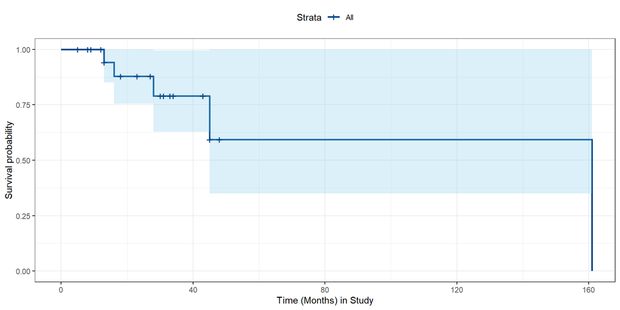

## Adding a “Number at Risk” Table

```r
ggsurvplot(km_aml, data = aml_432,
           ggtheme = theme_bw(), palette = "lancet",
           conf.int = TRUE,             # Add confidence interval
           conf.int.fill = "skyblue",
           risk.table = TRUE,           # Add risk table
           xlab = "Time (months)",      # Adjust X axis label
           break.time.by = 12           # X ticks every 12 months
   )
```

## Adding a “Number at Risk” Table

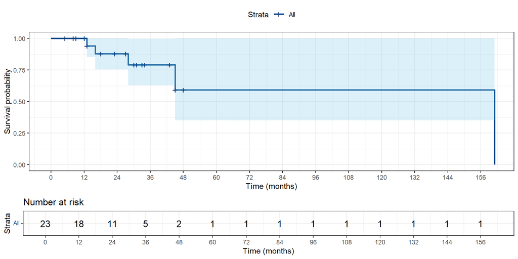

## Where We Are So Far

- Created a small (n = 23) tibble, `aml_432`.
- Observed 5 deaths, and 18 subjects censored before death.
- Survival object (containing time and fate) called `surv_aml`
- Created Kaplan-Meier estimate of survival function, `km_aml`.
- Plotted the Kaplan-Meier estimate with `ggsurvplot()`.
- Added a number at risk table to our Kaplan-Meier curve

Now, let’s consider a potential predictor (maintenance status) of our time-to-event outcome.

## Comparing Survival, by Group

Suppose we want to compare the survival functions for subjects classified by their maintenance group…

```r
aml_432 |>
  tabyl(maintain, death) |>
  adorn_totals(where = "col") |>
  adorn_title()
```

```
               death
      maintain     0 1 Total
    Maintained     7 4    11
 Nonmaintained    11 1    12
```

- In our sample, 4 of 11 in the “maintained” group and 1 of 12 in the “nonmaintained” group had the event (died).

## Survival Function, by Group

```r
km_aml_grp <- survfit(surv_aml ~ aml_432$maintain)
print(km_aml_grp, print.rmean = TRUE)
```

```
Call: survfit(formula = surv_aml ~ aml_432$maintain)

                                n events rmean* se(rmean) median 0.95LCL
aml_432$maintain=Maintained    11      4   97.2      28.4    103      28
aml_432$maintain=Nonmaintained 12      1  140.3      19.2     NA      NA
                               0.95UCL
aml_432$maintain=Maintained         NA
aml_432$maintain=Nonmaintained      NA
    * restricted mean with upper limit =  161
```

- 4 of 11 maintained subjects died; estimated restricted mean survival time is 97.2 months.
- 1 of 12 non-maintained subjects died, est. restricted mean survival = 140.3 months.

## Kaplan-Meier Plot, by Group

```r
ggsurvplot(km_aml_grp, data = aml_432,
           ggtheme = theme_bw(), palette = "lancet",
           conf.int = TRUE,
           xlab = "Time in months",
           break.time.by = 12,
           risk.table = TRUE,
           risk.table.height = 0.25,
           pval = TRUE)
```

## Kaplan-Meier Plot, by Group

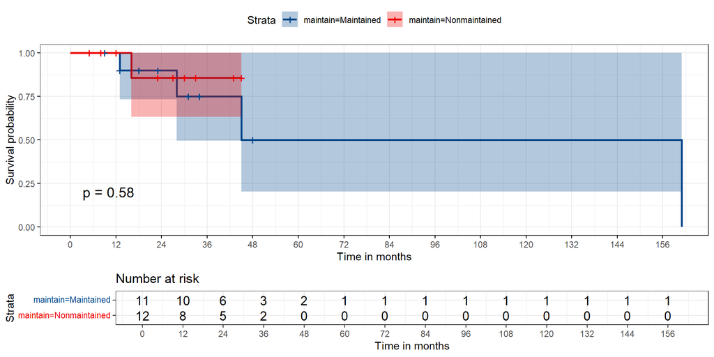

## Next Time: Time-to-event data

- Testing the difference between two survival curves
  - log rank tests
  - Peto-Peto modification of the Gehan-Wilcoxon test
- Customizing a Kaplan-Meier plot
  - Plotting Cumulative Event Rates
- A larger example
- Classes 22-23: Cox models for regression on time-to-event outcomes.

432 Class 15 | 2025-03-04 | https://thomaselove.github.io/432-2025/